# Stem-like CD8 T-cell Analysis — Initial Report

Cell recovery and inclusive co-expression of the requested stem-like CD8 markers

# Overview

The question is whether the CD8 scRNA-seq data contain cells with a transcriptional phenotype corresponding to the stem-like markers requested in the email:

**TCF1+, PD-1+, SLAMF6+, CD28+**, with possible **CCR7+ and/or CD62L+** characteristics.

For the scRNA-seq analysis, the corresponding genes are:

| Protein marker | RNA proxy |
| --- | --- |
| TCF1 | **TCF7** |
| PD-1 | **PDCD1** |
| SLAMF6 | **SLAMF6** |
| CD28 | **CD28** |
| CCR7 | **CCR7** |
| CD62L | **SELL** |

The purpose of this initial report is to determine:

1. whether sufficient CD8 cells were recovered in each experimental condition;
2. how many cells satisfy the requested marker combinations using **inclusive co-expression**;
3. whether the requested multi-marker populations are sufficiently represented for group-level analysis.

> **Practical analysis criterion:** For this type of cell-population comparison, we typically prefer **more than 100 cells per cell population in each group under analysis**. Populations substantially below this level are considered too sparsely represented for a robust group-level comparison in this initial analysis.

A further biological consideration is that several of these markers reflect a naïve/stem-like state; **PMA strongly activates T cells and can downregulate or alter this transcriptional program**, so loss of the RNA-defined combination after stimulation does not necessarily mean loss of the underlying cells.

> **Important limitation:** CITE-seq was not performed for these markers. The analysis therefore measures RNA co-detection rather than the protein-defined TCF1+ PD-1+ SLAMF6+ CD28+ phenotype.

# 1. Cell recovery before phenotype interpretation

The original analysis correctly examines cell recovery before interpreting phenotype frequencies. Lower numbers of recovered cells should not automatically be interpreted as cell death.

Recovered cells and CD8 representation by condition

| LaneGroup | Treatment | Total_cells | CD8_cells | Percent_CD8 |
| --- | --- | --- | --- | --- |
| untrained | Untreated | 27107 | 9144 | 33.7 |
| untrained | Treated | 23627 | 3468 | 14.7 |
| SYKi | Untreated | 23982 | 8789 | 36.6 |
| SYKi | Treated | 19903 | 2760 | 13.9 |
| MDP | Untreated | 25625 | 8347 | 32.6 |
| MDP | Treated | 26960 | 3620 | 13.4 |
| BG | Untreated | 24237 | 8321 | 34.3 |
| BG | Treated | 19191 | 2937 | 15.3 |

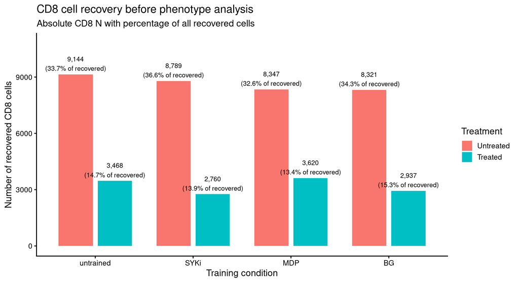

### Comment on cell recovery

The treated samples contain consistently fewer recovered CD8 cells than the corresponding untreated samples. In the current data, untreated groups contain approximately **8,300–9,100 CD8 cells**, whereas treated groups contain approximately **2,800–3,600 CD8 cells**. CD8 cells also represent a lower fraction of all recovered cells in treated samples (**13.4–15.3%**) than in untreated samples (**32.6–36.6%**).

This difference is important for the interpretation of the co-expression analysis. **Absolute numbers of marker-positive cells should not be compared by themselves across untreated and treated groups.** The percentage of CD8 cells carrying each phenotype is therefore shown together with the cell count in the heatmap. At this stage, the recovery difference should be treated as a sampling/recovery consideration rather than interpreted as evidence of CD8-cell loss.

# 2. Inclusive co-expression heatmap

This is the main first-report figure.

These are **inclusive combinations**. For example:

**TCF7 + CD28 + CCR7 + SELL**

means that a cell is positive for all four transcripts, regardless of whether **PDCD1** or **SLAMF6** are also detected.

Therefore:

**n(TCF7 + CD28 + CCR7 + SELL) ≤ n(TCF7)**

must always be true.

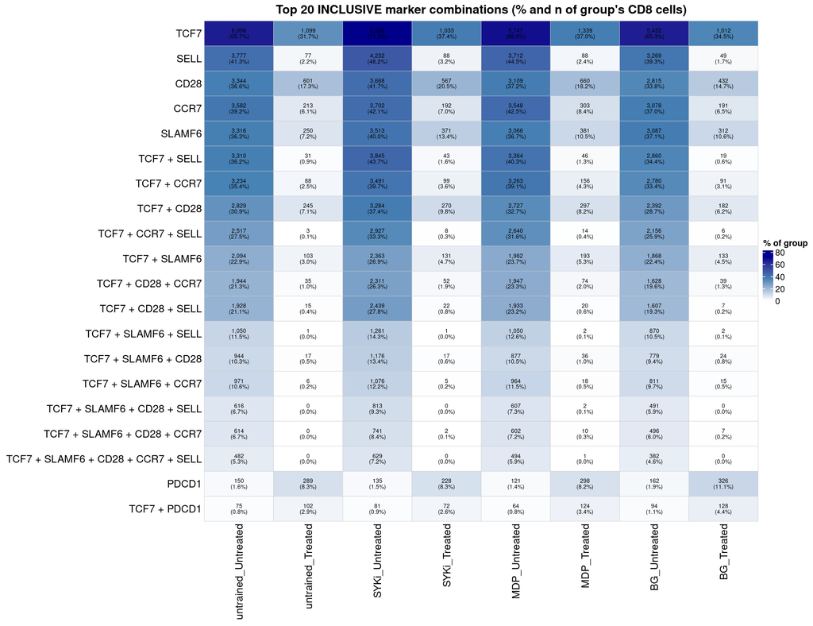

### Comment on inclusive co-expression

The heatmap separates two important observations.

First, the **TCF7 + SLAMF6 + CD28 + CCR7 + SELL** phenotype **without PDCD1** is well represented in every untreated group: **482 cells (5.3%) in untrained, 629 (7.2%) in SYKi, 494 (5.9%) in MDP, and 382 (4.6%) in BG**. These untreated populations are above the **>100 cells per population per group** that we typically prefer for this type of group-level analysis. SYKi_Untreated has the highest observed representation of this five-marker phenotype, although this heatmap alone does not establish that the difference is statistically or biologically significant.

Second, this same five-marker phenotype is essentially absent after treatment/PMA (**0, 0, 1, and 0 cells**, respectively). In contrast, **PDCD1 is more frequently detected in the treated groups**, while CCR7/SELL-containing stem-like or naïve-associated combinations collapse after stimulation. Thus, the limiting feature for the **originally requested phenotype** is the requirement for simultaneous **PDCD1** expression with the TCF7/SLAMF6/CD28/CCR7/SELL program, not a general absence of the stem-like/naïve-associated cells before stimulation.

**PMA is a strong activation stimulus and is expected to alter/downregulate naïve or stem-like transcriptional features such as CCR7/SELL/TCF7, so the near-loss of this RNA-defined phenotype after stimulation should not be interpreted as physical disappearance of the underlying cells.**

# 3. Summary

This section summarizes the main first-pass findings from the cell-recovery analysis and the inclusive co-expression analysis above.

A total of **47,386 CD8 cells** were identified from `predicted.celltype.l1` and included in this initial analysis.

The **TCF7 + SLAMF6 + CD28 + CCR7 + SELL** phenotype without PDCD1 is well represented before PMA/treatment, with **382 to 629 cells per untreated group**. After treatment/PMA, the same phenotype falls to **0 to 1 cells per group**.

For the requested RNA-defined core phenotype (**TCF7 + PDCD1 + SLAMF6 + CD28**), group-level frequencies range from **0.036% to 0.276%**, corresponding to **1 to 23 cells per group**.

When **CCR7** is added to the requested four-marker phenotype, the observed frequencies range from **0.000% to 0.156%** across groups.

When **SELL (CD62L)** is added to the requested four-marker phenotype, the observed frequencies range from **0.000% to 0.120%** across groups.

When all six transcripts are required simultaneously, group-level frequencies range from **0.000% to 0.084%**, corresponding to **0 to 7 cells per group**.

For this type of group-level cell-population analysis, we typically prefer **more than 100 cells per population in each group under analysis**. The five-marker **TCF7 + SLAMF6 + CD28 + CCR7 + SELL** population meets this practical criterion in every untreated group, but it is essentially absent after treatment/PMA. The originally requested phenotype that also requires **PDCD1** is much more sparsely represented and does not provide sufficient cell numbers for a robust multi-group comparison. Therefore, the data support a sizeable pre-stimulation TCF7/SLAMF6/CD28/CCR7/SELL population, while simultaneous PDCD1 expression is the limiting feature of the requested phenotype. Because PMA strongly alters activation state and naïve/stem-like transcriptional markers, the treated-versus-untreated difference should be interpreted as a change in RNA-defined phenotype rather than evidence that the cells themselves disappeared.

# Interpretation limitation

Because these are RNA measurements after stimulation and not CITE-seq protein measurements, the results should initially be described as a **stem-like CD8-associated transcriptional phenotype**. A low count for a strict multi-marker combination may reflect true rarity, sparse transcript detection, stimulation-associated transcriptional changes, or a combination of these factors.